# Covid Tracker

Buggers at covid19india.org changed their API so need to rework this

```r
setwd('~/Documents/work/data work/')
require(tidyverse)
```

```r
covidindia <- read_csv('https://api.covid19india.org/csv/latest/raw_data.csv', col_types = cols()) %>%
  mutate(`Age Bracket`=as.numeric(`Age Bracket`))
```

```
NAs introduced by coercion
```

```r
rd3 <- read_csv('https://api.covid19india.org/csv/latest/raw_data3.csv', col_types = cols()) %>%
  select(-`Contracted from which Patient (Suspected)`)
```

[output not shown]

```r
rd4 <- read_csv('https://api.covid19india.org/csv/latest/raw_data4.csv', col_types = cols()) %>%
  select(-`Contracted from which Patient (Suspected)`)
```

[output not shown]

```r
rd5 <- read_csv('https://api.covid19india.org/csv/latest/raw_data5.csv', col_types = cols()) %>%
  select(-`Contracted from which Patient (Suspected)`)
```

[output not shown]

```r
rd6 <- read_csv('https://api.covid19india.org/csv/latest/raw_data6.csv', col_types = cols()) %>%
  select(-`Contracted from which Patient (Suspected)`)
```

```
2 parsing failures.
  row         col               expected                                                             actual                                                    file
15509 Source_3    1/0/T/F/TRUE/FALSE     https://twitter.com/airnews_imphal/status/1271802373535526914?s=20 'https://api.covid19india.org/csv/latest/raw_data6.csv'
22515 Age Bracket no trailing characters  Months                                                            'https://api.covid19india.org/csv/latest/raw_data6.csv'
```

```r
rd3 %>%
  filter(`Current Status` != "Recovered") %>%
  distinct(`Patient Number`, .keep_all = T) %>%
  mutate(Date=as.Date(`Date Announced`, '%d/%m/%Y')) %>%
  rename(State=`Detected State`, District=`Detected District`, City=`Detected City`) %>%
  group_by(Date, State, District, City) %>%
  summarise(Cases=sum(`Num Cases`))
```

| Date | State | District | City | Cases |
| --- | --- | --- | --- | --- |
| 2020-04-27 | Andhra Pradesh | Guntur | NA | 23 |
| 2020-04-27 | Andhra Pradesh | Krishna | NA | 33 |
| 2020-04-27 | Andhra Pradesh | Kurnool | NA | 13 |
| 2020-04-27 | Andhra Pradesh | S.P.S. Nellore | NA | 7 |
| 2020-04-27 | Andhra Pradesh | Srikakulam | NA | 1 |
| 2020-04-27 | Andhra Pradesh | West Godavari | NA | 3 |
| 2020-04-27 | Bihar | Aurangabad | Jamhor | 2 |
| 2020-04-27 | Bihar | Aurangabad | Pawai | 3 |
| 2020-04-27 | Bihar | Bhojpur | Bhojpur | 3 |
| 2020-04-27 | Bihar | Bhojpur | Bihiya | 1 |

[output cut: 990 more lines]

```r
covidindia %>%
  mutate(Date=as.Date(`Date Announced`, '%d/%m/%Y')) %>%
  distinct(`Patient Number`, .keep_all = T) %>%
  rename(State=`Detected State`, District=`Detected District`, City=`Detected City`) %>%
  count(Date, State, District, City, name = 'Cases') %>%
  bind_rows(
    rd3 %>%
      filter(`Current Status` != "Recovered") %>%
      mutate(Date=as.Date(`Date Announced`, '%d/%m/%Y')) %>%
      rename(State=`Detected State`, District=`Detected District`, City=`Detected City`) %>%
      group_by(Date, State, District, City) %>%
      summarise(Cases=sum(`Num Cases`))
  ) %>%
  filter(!is.na(Cases)) ->
  dailyCases
```

```r
dailyCases %>%
  pull(Cases) %>%
  sum()
```

```
[1] 407978
```

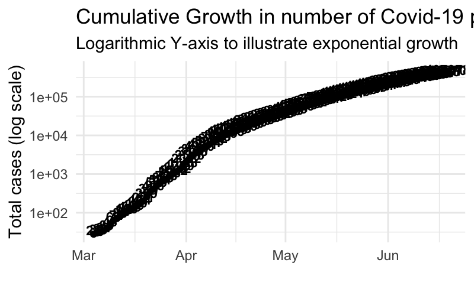

```r
dailyCases %>%
  group_by(Date) %>%
  summarise(n=sum(Cases)) %>%
  arrange(Date) %>%
  mutate(Cumul=cumsum(n)) %>%
  filter(Cumul > 20) %>%
  ggplot(aes(x=Date, y=Cumul)) + geom_point() + geom_line() + scale_y_log10("Total cases (log scale)") + geom_text(aes(label=Cumul), nudge_y=0.1, size=3, fontface='bold') + xlab("") + ggtitle("Cumulative Growth in number of Covid-19 positive cases in India", subtitle="Logarithmic Y-axis to illustrate exponential growth") + theme_minimal()
```

Show it instead in terms of doublign time

Smooth better using a 3-day CDGR

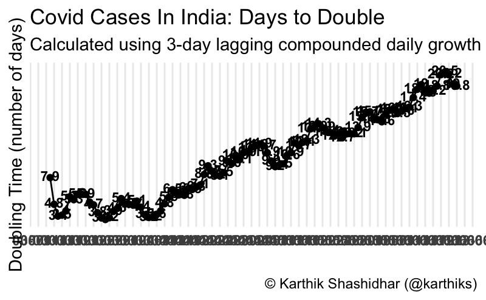

```r
dailyCases %>%
  filter(!is.na(Cases)) %>%
  group_by(Date) %>%
  summarise(n=sum(Cases)) %>%
  arrange(Date) %>%
  mutate(Cumul=cumsum(n)) %>%
  filter(Cumul >= 30) %>%
  mutate(
    Growth3=log(Cumul/lag(Cumul,3)),
    DoublingTime3=log(2)/Growth3*3
  ) %>%
  filter(!is.na(DoublingTime3)  & Date < Sys.Date()) %>%
  ggplot(aes(x=Date, y=DoublingTime3)) + geom_point() + geom_line()  + scale_y_continuous("Doubling Time (number of days)", breaks=c()) + theme_minimal() + geom_text(aes(label=round(DoublingTime3,1)), nudge_y=0.2, fontface='bold', size=3) + labs(title="Covid Cases In India: Days to Double", subtitle = "Calculated using 3-day lagging compounded daily growth rate", caption="© Karthik Shashidhar (@karthiks)") + scale_x_date('',date_breaks = '2 days', date_labels = '%d-%m') + theme(panel.grid.minor = element_blank(), axis.text = element_text(face='bold'))
```

Let’s plot the growth rate as well

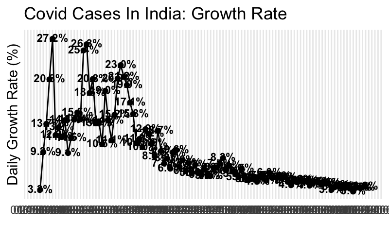

```r
dailyCases %>%
  group_by(Date) %>%
  summarise(n=sum(Cases)) %>%
  filter(!is.na(Date)) %>%
  arrange(Date) %>%
  mutate(Cumul=cumsum(n)) %>%
  filter(Cumul >= 30) %>%
  mutate(
    Growth1=log(Cumul/lag(Cumul,1)),
    Days=log(2)/Growth1
  ) %>%
  filter(!is.na(Growth1) ) %>%
  ggplot(aes(x=Date, y=Growth1)) + geom_point() + geom_line()  + scale_y_continuous("Daily Growth Rate (%)", breaks=c()) + theme_minimal() + geom_text(aes(label=scales::percent(Growth1, .1)), nudge_y=0.002, fontface='bold', size=3) + ggtitle("Covid Cases In India: Growth Rate") + scale_x_date('',date_breaks = '1 day', date_labels = '%d/%m') + theme(panel.grid.minor = element_blank())
```

[figure not shown]

```r
dailyCases %>%
  group_by(Date, State) %>%
  summarise(n=sum(Cases)) %>%
  ungroup() %>%
  complete(Date, State, fill=list(n=0)) %>%
  group_by(State) %>%
  arrange(Date) %>%
  mutate(Cumul=cumsum(n),Total=sum(n)) %>%
  filter(Cumul >= 5 & Total >= 50) %>%  # ignore small states or states without much data
  mutate(
    Growth3=log(Cumul/lag(Cumul,3)),
    DoublingTime3=log(2)/Growth3*3,
    LastGrowth=Growth3[Date==max(Date)],
    LastDouble=DoublingTime3[Date==max(Date)]
  ) %>%
  filter(!is.na(DoublingTime3) & Date >= as.Date('2020-03-26')) %>%
  mutate(StateCase=paste(State, paste(Total, 'total cases'), paste("Now doubling every", round(LastDouble, 1), "days"),  sep='\n')) %>%
  ggplot(aes(x=Date, y=DoublingTime3)) + geom_point() + geom_line()  + scale_y_continuous("Doubling Time (number of days)", breaks=c()) + theme_minimal() + geom_text(aes(label=round(DoublingTime3,1), y=1.1*DoublingTime3), fontface='bold', size=3) + labs(title="Covid Cases In India: Days to Double", subtitle = "Calculated using 3-day lagging compounded daily growth rate", caption="© Karthik Shashidhar (@karthiks)" ) + scale_x_date('') + facet_wrap(~reorder(StateCase, LastGrowth), scales='free') + theme(strip.text = element_text(face='bold', hjust=0), panel.grid.minor = element_blank(), axis.text = element_text(face='bold'))
```

Let’s do this by district

[figure not shown]

```r
dailyCases %>%
  group_by(Date, State, District) %>%
  summarise(n=sum(Cases)) %>%
  ungroup() %>%
  mutate(State=paste0(District, ' (', State, ')')) %>%
  group_by(Date, State) %>%
  summarise(n=sum(n)) %>%
  ungroup() %>%
  complete(Date, State, fill=list(n=0)) %>%
  group_by(State) %>%
  arrange(Date) %>%
  mutate(Cumul=cumsum(n),Total=sum(n)) %>%
  filter(Cumul >= 5 & Total >= 150) %>%  # ignore small states or states without much data
  mutate(
    Growth3=log(Cumul/lag(Cumul,3)),
    DoublingTime3=log(2)/Growth3*3,
    LastGrowth=Growth3[Date==max(Date)],
    LastDouble=DoublingTime3[Date==max(Date)]
  ) %>%
  filter(!is.na(DoublingTime3) & Date==max(Date) & DoublingTime3 < 50 & DoublingTime3 > 0) %>%
  mutate(StateCase=paste0(State, ' (',Total, ')'))%>%
  ggplot(aes(x=reorder(StateCase, LastDouble), y=LastDouble, fill=log(Total), label=round(LastDouble, 1))) + geom_col() + geom_text(size=2.3, aes(y=ifelse(LastDouble < 6, LastDouble + 1, LastDouble - 1), col=ifelse(LastDouble < 6, 'black', 'white')), fontface='bold') + scale_y_continuous("Days to double", breaks=c()) + theme_minimal() + labs(title="Covid Cases By District In India: Days to Double", subtitle = "Calculated using 3-day lagging compounded daily growth rate", caption="© Karthik Shashidhar (@karthiks)\n Data source: covid19india.org" ) + xlab('') + coord_flip() + theme(panel.grid.minor = element_blank(), axis.text = element_text(face='bold'), legend.position = 'none') + scale_fill_gradient() + scale_colour_identity() + geom_hline(yintercept = 14, col='red', lwd=0.5)
```

[figure not shown]

```r
dailyCases %>%
  group_by(Date, State, District) %>%
  summarise(n=sum(Cases)) %>%
  ungroup() %>%
  mutate(State=paste0(District, ' (', State, ')')) %>%
  group_by(Date, State) %>%
  summarise(n=sum(n)) %>%
  ungroup() %>%
  complete(Date, State, fill=list(n=0)) %>%
  group_by(State) %>%
  arrange(Date) %>%
  mutate(Cumul=cumsum(n),Total=sum(n)) %>%
  filter(Cumul >= 5 & Total >= 200) %>%  # ignore small states or states without much data
  mutate(
    Growth3=log(Cumul/lag(Cumul,3)),
    DoublingTime3=log(2)/Growth3*3,
    LastGrowth=Growth3[Date==max(Date)],
    LastDouble=DoublingTime3[Date==max(Date)]
  ) %>%
  filter(!is.na(DoublingTime3) & Date >= Sys.Date() - 10) %>%
  mutate(StateCase=paste(State, paste(Total, 'total cases'), paste("Now doubling every", round(LastDouble, 1), "days"),  sep='\n')) %>%
  ggplot(aes(x=Date, y=DoublingTime3)) + geom_point() + geom_line()  + scale_y_continuous("Doubling Time (number of days)", breaks=c()) + theme_minimal() + geom_text(aes(label=round(DoublingTime3,1), y=1.1*DoublingTime3), fontface='bold', size=3) + labs(title="Covid Cases In India: Days to Double", subtitle = "Calculated using 3-day lagging compounded daily growth rate", caption="© Karthik Shashidhar (@karthiks)" ) + scale_x_date('') + facet_wrap(~reorder(StateCase, LastGrowth), scales='free') + theme(strip.text = element_text(face='bold', hjust=0), panel.grid.minor = element_blank(), axis.text = element_text(face='bold'))
```

Do the bar graph only for Karnataka

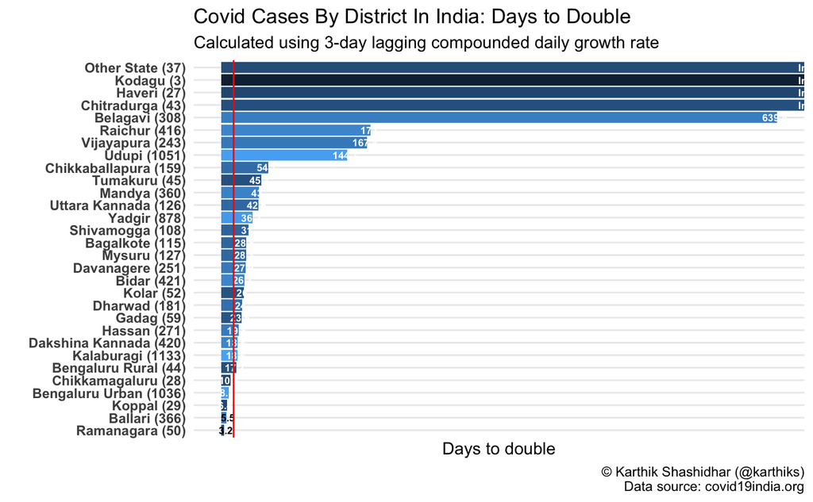

```r
dailyCases %>%
  group_by(Date, State, District) %>%
  summarise(n=sum(Cases)) %>%
  ungroup() %>%
  filter(State=='Karnataka') %>%
  mutate(State=District) %>%
  group_by(Date, State) %>%
  summarise(n=sum(n)) %>%
  ungroup() %>%
  complete(Date, State, fill=list(n=0)) %>%
  group_by(State) %>%
  arrange(Date) %>%
  mutate(Cumul=cumsum(n),Total=sum(n)) %>%
  filter(Cumul >= 3 & Total >= 3) %>%  # ignore small states or states without much data
  mutate(
    Growth3=log(Cumul/lag(Cumul,3)),
    DoublingTime3=log(2)/Growth3*3,
    LastGrowth=Growth3[Date==max(Date)],
    LastDouble=DoublingTime3[Date==max(Date)]
  ) %>%
  filter(!is.na(DoublingTime3) & Date==max(Date)) %>%
  mutate(StateCase=paste0(State, ' (',Total, ')'))%>%
  ggplot(aes(x=reorder(StateCase, LastDouble), y=LastDouble, fill=log(Total), label=round(LastDouble, 1))) + geom_col() + geom_text(size=2.3, aes(y=ifelse(LastDouble < 6, LastDouble + 2, LastDouble - 2), col=ifelse(LastDouble < 6, 'black', 'white')), fontface='bold') + scale_y_continuous("Days to double", breaks=c()) + theme_minimal() + labs(title="Covid Cases By District In India: Days to Double", subtitle = "Calculated using 3-day lagging compounded daily growth rate", caption="© Karthik Shashidhar (@karthiks)\n Data source: covid19india.org" ) + xlab('') + coord_flip() + theme(panel.grid.minor = element_blank(), axis.text = element_text(face='bold'), legend.position = 'none') + scale_fill_gradient() + scale_colour_identity() + geom_hline(yintercept = 14, col='red', lwd=0.5)
```

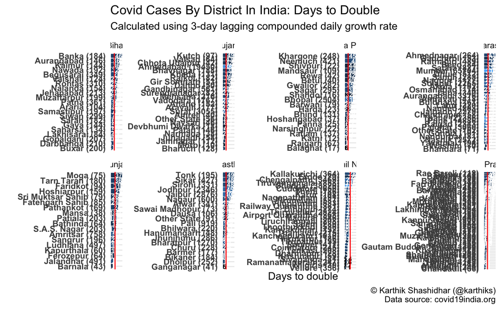

```r
dailyCases %>%
  filter(!is.na(Date) & State %in% c('Uttar Pradesh',"Bihar", "Tamil Nadu", "Gujarat", "Rajasthan", "Madhya Pradesh", "Maharashtra", "Punjab")) %>%
  group_by(Date, State, District) %>%
  summarise(n=sum(Cases)) %>%
  group_by(State) %>%
  complete(Date, District, fill=list(n=0)) %>%
  group_by(State, District) %>%
  arrange(Date) %>%
  mutate(Cumul=cumsum(n),Total=sum(n)) %>%
  filter(Cumul >= 3 & Total >= 10) %>%  # ignore small states or states without much data
  mutate(
    Growth3=log(Cumul/lag(Cumul,3)),
    DoublingTime3=log(2)/Growth3*3,
    LastGrowth=Growth3[Date==max(Date)],
    LastDouble=DoublingTime3[Date==max(Date)]
  ) %>%
  filter(!is.na(DoublingTime3) & Date==max(Date) & DoublingTime3 <= 50 & DoublingTime3 >0) %>%
  mutate(StateCase=paste0(District, ' (',Total, ')'))%>%
  ggplot(aes(x=reorder(StateCase, LastDouble), y=LastDouble, fill=log(Total), label=round(LastDouble, 1))) + geom_col() + geom_text(size=2.3, aes(y=ifelse(LastDouble < 6, LastDouble + 2, LastDouble - 2), col=ifelse(LastDouble < 6, 'black', 'white')), fontface='bold') + scale_y_continuous("Days to double", breaks=c()) + theme_minimal() + labs(title="Covid Cases By District In India: Days to Double", subtitle = "Calculated using 3-day lagging compounded daily growth rate", caption="© Karthik Shashidhar (@karthiks)\n Data source: covid19india.org" ) + xlab('') + coord_flip() + theme(panel.grid.minor = element_blank(), axis.text = element_text(face='bold'), legend.position = 'none') + scale_fill_gradient() + scale_colour_identity() + facet_wrap(~State, scales='free', nrow=2) + geom_hline(yintercept = 14, col='red', lwd=0.5)
```

Only for Karnataka

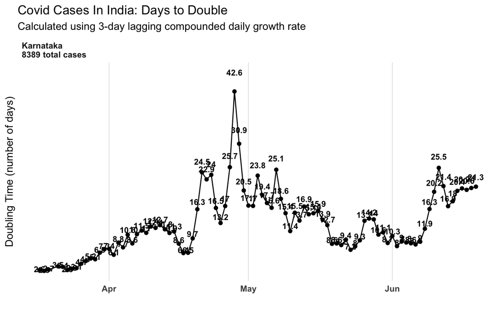

```r
dailyCases %>%
  filter(State=="Karnataka") %>%
  group_by(Date, State) %>%
  summarise(n=sum(Cases)) %>%
  ungroup() %>%
  complete(Date, State, fill=list(n=0)) %>%
  group_by(State) %>%
  arrange(Date) %>%
  mutate(Cumul=cumsum(n),Total=sum(n)) %>%
  filter(Cumul >= 5 & Total >= 50) %>%  # ignore small states or states without much data
  mutate(
    Growth3=log(Cumul/lag(Cumul,3)),
    DoublingTime3=log(2)/Growth3*3,
    LastGrowth=Growth3[Date==max(Date)]
  ) %>%
  filter(!is.na(DoublingTime3) ) %>%
  mutate(StateCase=paste(State, paste(Total, 'total cases'), sep='\n')) %>%
  ggplot(aes(x=Date, y=DoublingTime3)) + geom_point() + geom_line()  + scale_y_continuous("Doubling Time (number of days)", breaks=c()) + theme_minimal() + geom_text(aes(label=round(DoublingTime3,1), y=1.1*DoublingTime3), fontface='bold', size=3) + ggtitle("Covid Cases In India: Days to Double", subtitle = "Calculated using 3-day lagging compounded daily growth rate") + scale_x_date('') + facet_wrap(~reorder(StateCase, LastGrowth), scales='free') + theme(strip.text = element_text(face='bold', hjust=0), panel.grid.minor = element_blank(), axis.text = element_text(face='bold'))
```

State wise absolute

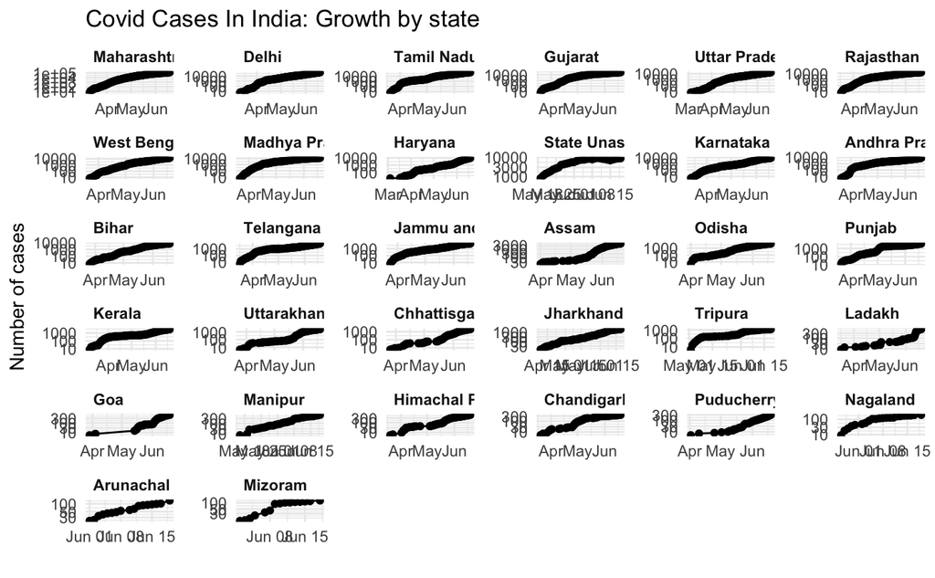

```r
dailyCases %>%
  group_by(Date, State) %>%
  summarise(n=sum(Cases)) %>%
  filter(!is.na(Date)) %>%
  group_by(State) %>%
  arrange(Date) %>%
  mutate(Cumul=cumsum(n),Total=sum(n)) %>%
  filter(Cumul >= 5 & Total >= 100) %>% # ignore small states or states without much data
  ggplot(aes(x=Date, y=Cumul)) + geom_point() + geom_line() + scale_y_log10("Number of cases") + theme_minimal() + facet_wrap(~reorder(State, -Total), scales='free') + ggtitle("Covid Cases In India: Growth by state") + scale_x_date('')  + theme(strip.text = element_text(face='bold', hjust=0))
```

[figure not shown]

```r
dailyCases %>%
  group_by(Date, State) %>%
  summarise(n=sum(Cases)) %>%
  ungroup() %>%
  complete(Date, State, fill=list(n=0)) %>%
  filter(!is.na(Date)) %>%
  group_by(State) %>%
  arrange(State, Date) %>%
  mutate(
    Cumul=cumsum(n),
    Today=sum(n),
    Lag7=Cumul[Date==(max(Date)-7)],
    Growth7=log(Today/Lag7)/7,
    Lag3=Cumul[Date==(max(Date)-3)],
    Growth3=log(Today/Lag3)/3,
    Lag2=Cumul[Date==(max(Date)-2)],
    Growth2=log(Today/Lag2)/2,
    GrowthRate=pmax(Growth7, Growth3, Growth2),
    Forecast2weeks=Today*exp(14*GrowthRate)  - Today,  # People infected until today would have bee cured in 2 weeks' time,
    Colour=ifelse(GrowthRate <= log(2)/30, 'yellow', ifelse(GrowthRate <= log(2)/7, 'orange', 'red'))
  ) %>%
  ungroup() %>%
  mutate(StateLabel=paste(State, paste(signif(round(Forecast2weeks),3), 'active cases on', format(Sys.Date()+14, '%d-%b')), sep='\n')) %>%
  filter(Cumul >= 5 & Today >= 50) ->  # ignore small states or states without much data
  stateCumul
stateCumul %>%
  ggplot(aes(x=Date, y=Cumul, col=Colour)) + geom_point() + geom_line() + scale_y_log10("Number of cases") + theme_minimal() + geom_text(aes(label=n, y=1.5*Cumul), fontface='bold', size=2) + facet_wrap(~reorder(StateLabel, -Forecast2weeks), scales='free') + labs(title="Covid Cases In India: Growth by state", subtitle="14 day projection based on maximum of 2-day, 3-day and 7-day growth rate in cases", caption="© Karthik Shashidhar (@karthiks)") + scale_x_date('')  + theme(strip.text = element_text(face='bold', hjust=0)) + scale_colour_identity()
```

The above graph was misleading. Let me change it up so that we now have active cases per day, assuming a recovery period of 14 days, and a growth equal to max of 2, 3, 7 day growth

[figure not shown]

```r
dailyCases %>%
  filter(!is.na(Date)) %>%
  group_by(Date, State) %>%
  summarise(n=sum(Cases)) %>%
  ungroup() %>%
  complete(Date, State, fill=list(n=0)) %>%
  group_by(State) %>%
  arrange(State, Date) %>%
  mutate(
    Cumul=cumsum(n),
    Today=sum(n),
    Lag7=Cumul[Date==(max(Date)-7)],
    Growth7=log(Today/Lag7)/7,
    Lag3=Cumul[Date==(max(Date)-3)],
    Growth3=log(Today/Lag3)/3,
    Lag2=Cumul[Date==(max(Date)-2)],
    Growth2=log(Today/Lag2)/2,
    GrowthRate=pmax(Growth7, Growth3, Growth2),
    Colour=ifelse(GrowthRate <= log(2)/30, 'yellow', ifelse(GrowthRate <= log(2)/7, 'orange', 'red'))
  ) %>%
  select(Date, State, Cumul, GrowthRate, Colour, Today) %>%
  inner_join(
    (.) %>%
      filter(Date==max(Date)) %>%
      select(Date, State, Today, GrowthRate) %>%
      crossing(Projection=0:14) %>%
      mutate(
        ProjectedDate=Date + Projection,
        ProjectedCases=Today * exp(Projection * GrowthRate),
        Date=ProjectedDate-14
      ) %>%
      select(-GrowthRate, -Today, -Projection),
    by=c("State", "Date")
  ) %>%
  mutate(
    LiveCases=ProjectedCases-Cumul,
    StateLabel=paste(State, paste(signif(round(Today*exp(14*GrowthRate)-Today),3), 'active cases on', format(Sys.Date()+14, '%d-%b')), sep='\n')
  ) %>%
  filter(Cumul >= 5 & Today >= 50) %>%
  ggplot(aes(x=ProjectedDate, y=LiveCases, col=Colour)) + geom_point() + geom_line() + scale_y_continuous("Number of cases", labels=scales::label_number_si()) + theme_minimal() + geom_text(aes(label=round(LiveCases), y=1.1*LiveCases), fontface='bold', size=2) + facet_wrap(~reorder(StateLabel, -Today*exp(GrowthRate*14)), scales='free') + labs(title="Covid Cases In India: Growth by state", subtitle="14 day projection based on maximum of 2-day, 3-day and 7-day growth rate in cases\nAssuming a constant 14-day recovery period", caption="© Karthik Shashidhar (@karthiks)") + scale_x_date('')  + theme(strip.text = element_text(face='bold', hjust=0)) + scale_colour_identity()
```

```r
dailyCases %>%
  mutate(Region=coalesce(City, District, State)) %>%
  group_by(Date, Region) %>%
  summarise(Cases=sum(Cases))
```

| Date | Region | Cases |
| --- | --- | --- |
| 2020-01-30 | Thrissur | 1 |
| 2020-02-02 | Alappuzha | 1 |
| 2020-02-03 | Kasaragod | 1 |
| 2020-03-02 | East Delhi (Mayur Vihar) | 1 |
| 2020-03-02 | Hyderabad | 1 |
| 2020-03-03 | Jaipur | 1 |
| 2020-03-04 | Agra | 7 |
| 2020-03-04 | Gurugram | 14 |
| 2020-03-04 | Jaipur | 1 |
| 2020-03-05 | Ghaziabad | 1 |

[output cut: 990 more lines]

```r
covidindia %>%
  filter(`Detected State`=='Karnataka') %>%
  bind_rows(
    rd3 %>%
      filter(`Detected State`=='Karnataka' & `Current Status` !='Recovered' & !is.na(`State Patient Number`))
  ) %>%
  mutate(Date=as.Date(`Date Announced`, '%d/%m/%Y'))  %>%
  select(Date, StateID=`State Patient Number`, City=`Detected City`, District=`Detected District`,Status=`Current Status`, Notes=Notes, Age=`Age Bracket`, Sex=Gender, Transmission=`Type of transmission`, MoreNotes=`Backup Notes`) %>%
  mutate(Notes=str_sub(Notes, 1, 60)) %>%
  filter(!str_detect(str_to_lower(Notes), 'travel') & !str_detect(str_to_lower(Notes), 'return')) %>%
  arrange(desc(Date), District, desc(StateID))
```

| Date | StateID | City | District | Status | Notes | Age | Sex | Transmission | MoreNotes |
| --- | --- | --- | --- | --- | --- | --- | --- | --- | --- |
| 2020-06-19 | KA-P7999 | NA | Ballari | Hospitalized | Contact under tracing | 33.0 | M | NA | NA |
| 2020-06-19 | KA-P7998 | NA | Ballari | Hospitalized | Contact under tracing | 46.0 | F | NA | NA |
| 2020-06-19 | KA-P7997 | NA | Ballari | Hospitalized | Contact under tracing | 57.0 | M | NA | NA |
| 2020-06-19 | KA-P7996 | NA | Ballari | Hospitalized | Contact of P-6493 | 44.0 | M | NA | NA |
| 2020-06-19 | KA-P7995 | NA | Ballari | Hospitalized | Contact under tracing | 25.0 | M | NA | NA |
| 2020-06-19 | KA-P7994 | NA | Ballari | Hospitalized | Contact of P-7439 | 34.0 | M | NA | NA |
| 2020-06-19 | KA-P7993 | NA | Ballari | Hospitalized | Contact under tracing | 26.0 | M | NA | NA |
| 2020-06-19 | KA-P7992 | NA | Ballari | Hospitalized | Contact under tracing | 22.0 | M | NA | NA |
| 2020-06-19 | KA-P7991 | NA | Ballari | Hospitalized | Contact of P-6995 | 18.0 | M | NA | NA |
| 2020-06-19 | KA-P7990 | NA | Ballari | Hospitalized | ILI | 23.0 | M | NA | NA |

[output cut: 990 more lines]

```r
covidindia %>%
  filter(`Detected State`=='Karnataka') %>%
  bind_rows(
    rd3 %>%
      filter(`Detected State`=='Karnataka' & `Current Status` !='Recovered' & !is.na(`State Patient Number`))
  ) %>%
  mutate(Date=as.Date(`Date Announced`, '%d/%m/%Y'))  %>%
  count(Date)
```

| Date | n |
| --- | --- |
| 2020-03-09 | 1 |
| 2020-03-10 | 3 |
| 2020-03-12 | 1 |
| 2020-03-13 | 1 |
| 2020-03-16 | 1 |
| 2020-03-17 | 4 |
| 2020-03-18 | 3 |
| 2020-03-19 | 1 |
| 2020-03-21 | 5 |
| 2020-03-22 | 6 |

[output cut: 89 more lines]

```r
covidindia %>%
  filter(`Detected State`=='Karnataka') %>%
  bind_rows(
    rd3 %>%
      filter(`Detected State`=='Karnataka' & `Current Status` !='Recovered' & !is.na(`State Patient Number`))
  ) %>%
  mutate(Date=as.Date(`Date Announced`, '%d/%m/%Y'))  %>%
  filter(`Detected District`=='Bengaluru Urban') %>%
  select(Date, StateID=`State Patient Number`,Status=`Current Status`, Notes=Notes, Age=`Age Bracket`, Sex=Gender, Transmission=`Type of transmission`, MoreNotes=`Backup Notes`) %>%
  mutate(Notes=str_sub(Notes, 1, 60)) %>%
  arrange(desc(Date), desc(StateID))
```

| Date | StateID | Status | Notes | Age | Sex | Transmission | MoreNotes |
| --- | --- | --- | --- | --- | --- | --- | --- |
| 2020-06-19 | KA-P8226 | Hospitalized | Contact under tracing | 22.00 | F | NA | NA |
| 2020-06-19 | KA-P8225 | Hospitalized | ILI | 15.00 | F | NA | NA |
| 2020-06-19 | KA-P8224 | Hospitalized | ILI | 42.00 | M | NA | NA |
| 2020-06-19 | KA-P8223 | Hospitalized | ILI | 39.00 | F | NA | NA |
| 2020-06-19 | KA-P8222 | Hospitalized | SARI | 39.00 | M | NA | NA |
| 2020-06-19 | KA-P8221 | Hospitalized | Contact under tracing | 33.00 | M | NA | NA |
| 2020-06-19 | KA-P8220 | Hospitalized | ILI | 43.00 | M | NA | NA |
| 2020-06-19 | KA-P8219 | Hospitalized | Contact under tracing | 41.00 | M | NA | NA |
| 2020-06-19 | KA-P8218 | Hospitalized | ILI | 57.00 | M | NA | NA |
| 2020-06-19 | KA-P8217 | Hospitalized | ILI | 38.00 | M | NA | NA |

[output cut: 990 more lines]

```r
covidindia %>%
  filter(`Detected State`=='Karnataka') %>%
  bind_rows(
    rd3 %>%
      filter(`Detected State`=='Karnataka' & `Current Status` !='Recovered' & !is.na(`State Patient Number`))
  ) %>%
  mutate(Date=as.Date(`Date Announced`, '%d/%m/%Y')) %>%
  group_by(Notes, `Detected District`) %>%
  summarise(Num=n(), Earliest=min(Date)) %>%
  arrange(-Num) %>%
  filter(Num>=5)
```

| Notes | Detected District | Num | Earliest |
| --- | --- | --- | --- |
| Travelled from Maharashtra | Udupi | 660 | 2020-05-24 |
| Travelled from Maharashtra | Yadgir | 497 | 2020-05-24 |
| Travelled from Maharashtra | Kalaburagi | 456 | 2020-05-24 |
| Returnee from Maharashtra | Kalaburagi | 416 | 2020-05-25 |
| Returnee from Maharashtra | Yadgir | 257 | 2020-05-25 |
| Returnee from Maharashtra | Udupi | 222 | 2020-05-25 |
| Travelled from Maharashtra | Raichur | 176 | 2020-05-21 |
| Contact under tracing | Bengaluru Urban | 159 | 2020-05-08 |
| ILI | Bengaluru Urban | 159 | 2020-06-06 |
| Travelled from Maharashtra | Belagavi | 146 | 2020-05-31 |

[output cut: 215 more lines]

```r
covidindia %>%
  filter(`Detected State`=='Karnataka') %>%
  bind_rows(
    rd3 %>%
      filter(`Detected State`=='Karnataka' & `Current Status` !='Recovered' & !is.na(`State Patient Number`))
  ) %>%
  mutate(Date=as.Date(`Date Announced`, '%d/%m/%Y')) %>%
  group_by(Notes) %>%
  summarise(Num=n(), Earliest=min(Date)) %>%
  arrange(-Num) %>%
  filter(Num>=5)
```

| Notes | Num | Earliest |
| --- | --- | --- |
| Travelled from Maharashtra | 2508 | 2020-05-21 |
| Returnee from Maharashtra | 1506 | 2020-05-25 |
| Contact under tracing | 424 | 2020-05-08 |
| ILI | 257 | 2020-05-25 |
| Returnees for Maharashtra | 176 | 2020-05-23 |
| International travel from UAE | 149 | 2020-05-25 |
| SARI | 147 | 2020-04-08 |
| Travelled from Maharastra | 108 | 2020-05-27 |
| Inter State Travel History – Mumbai , Maharashtra | 87 | 2020-05-19 |
| Returnees from Maharashtra State | 84 | 2020-05-22 |

[output cut: 118 more lines]

```r
covidindia %>%
  filter(`Detected State`=='Karnataka') %>%
  bind_rows(
    rd3 %>%
      filter(`Detected State`=='Karnataka' & `Current Status` !='Recovered' & !is.na(`State Patient Number`))
  ) %>%
  mutate(
    Date=as.Date(`Date Announced`, '%d/%m/%Y'),
    MH=str_detect(Notes, 'Mumbai') | str_detect(Notes, 'Maharashtra') | str_detect(Notes, "Maharastra")
  ) %>%
  count(MH, Date) %>%
  group_by(Date) %>%
  summarise(MH=sum(n[MH], na.rm=T)/sum(n, na.rm=T)) %>%
  arrange(desc(Date))
```

| Date | MH |
| --- | --- |
| 2020-06-19 | 0.21325648 |
| 2020-06-18 | 0.21171171 |
| 2020-06-17 | 0.48584906 |
| 2020-06-16 | 0.30555556 |
| 2020-06-15 | 0.39906103 |
| 2020-06-14 | 0.45303867 |
| 2020-06-13 | 0.65048544 |
| 2020-06-12 | 0.31294964 |
| 2020-06-11 | 0.71497585 |
| 2020-06-10 | 0.53658537 |

[output cut: 89 more lines]

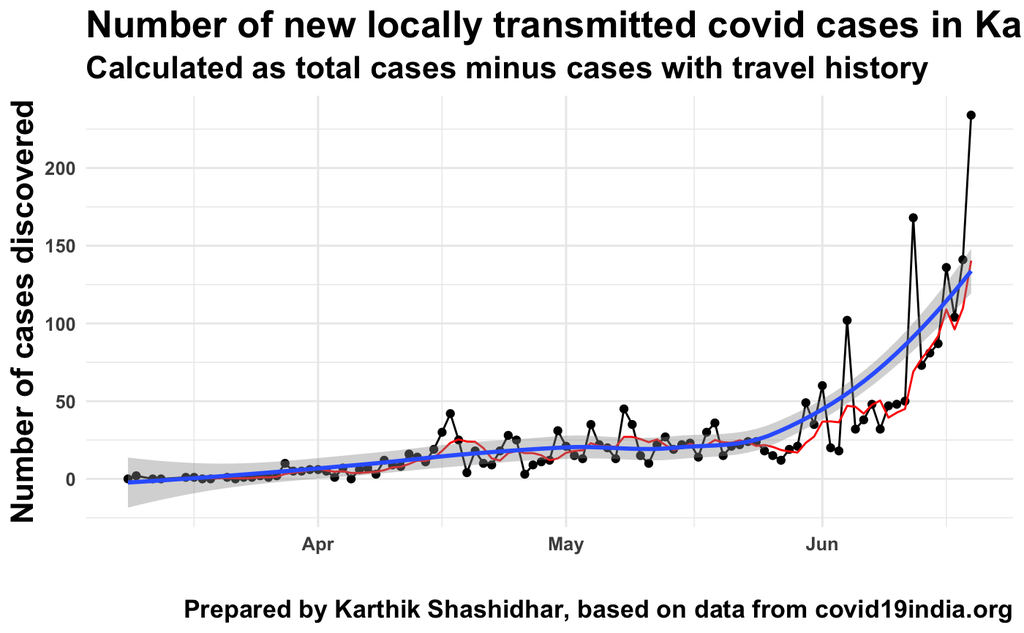

```r
covidindia %>%
  filter(`Detected State`=='Karnataka') %>%
  bind_rows(
    rd3 %>%
      filter(`Detected State`=='Karnataka' & `Current Status` !='Recovered' & !is.na(`State Patient Number`))
  ) %>%
  mutate(
    Date=as.Date(`Date Announced`, '%d/%m/%Y'),
    Travel=str_detect(str_to_lower(Notes), 'travel') | str_detect(str_to_lower(Notes), 'return')
  ) %>%
  count(Travel, Date) %>%
  group_by(Date) %>%
  summarise(Travel=sum(n[Travel], na.rm=T), Total=sum(n, na.rm=T)) %>%
  mutate(Local=Total-Travel) %>%
  arrange(Date) %>%
  mutate(SmoothLocal=(Local+lag(Local,1)+lag(Local,2)+lag(Local,3)+lag(Local,4))/5) %>%
  ggplot(aes(x=Date, y=Local)) + geom_point() + geom_line() + geom_line(aes(y=SmoothLocal), col='red', lwd=0.5) +  geom_smooth(method='loess', formula='y~x', se=T) + theme_minimal() + xlab('') + ylab("Number of cases discovered") + labs(title='Number of new locally transmitted covid cases in Karnataka by date of discovery', subtitle='Calculated as total cases minus cases with travel history', caption='Prepared by Karthik Shashidhar, based on data from covid19india.org') + theme(title=element_text(size=16, face='bold'), text=element_text(size=12, face='bold'))
```

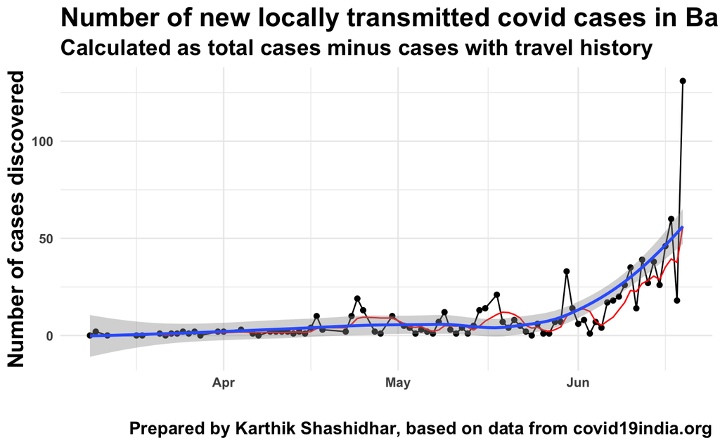

```r
covidindia %>%
  filter(`Detected State`=='Karnataka') %>%
  bind_rows(
    rd3 %>%
      filter(`Detected State`=='Karnataka' & `Current Status` !='Recovered' & !is.na(`State Patient Number`))
  ) %>%
  filter(`Detected District`=='Bengaluru Urban') %>%
  mutate(
    Date=as.Date(`Date Announced`, '%d/%m/%Y'),
    Travel=str_detect(str_to_lower(Notes), 'travel') | str_detect(str_to_lower(Notes), 'return')
  ) %>%
  count(Travel, Date) %>%
  group_by(Date) %>%
  summarise(Travel=sum(n[Travel], na.rm=T), Total=sum(n, na.rm=T)) %>%
  mutate(Local=Total-Travel) %>%
  arrange(Date) %>%
  mutate(SmoothLocal=(Local+lag(Local,1)+lag(Local,2)+lag(Local,3)+lag(Local,4))/5) %>%
  ggplot(aes(x=Date, y=Local)) + geom_point() + geom_line() + geom_line(aes(y=SmoothLocal), col='red', lwd=0.5) + geom_smooth(method='loess', formula='y~x', se=T) + theme_minimal() + xlab('') + ylab("Number of cases discovered") + labs(title='Number of new locally transmitted covid cases in Bangalore by date of discovery', subtitle='Calculated as total cases minus cases with travel history', caption='Prepared by Karthik Shashidhar, based on data from covid19india.org') + theme(title=element_text(size=16, face='bold'), text=element_text(size=12, face='bold'))
```

Let’s try and build a graph for Karnataka

```r
covidindia %>%
  filter(`Detected State`=='Karnataka') %>%
  bind_rows(
    rd3 %>%
      filter(`Detected State`=='Karnataka' & `Current Status` !='Recovered' & !is.na(`State Patient Number`))
  ) %>%
  mutate(Date=as.Date(`Date Announced`, '%d/%m/%Y'))  %>%
  select(Date, StateID=`State Patient Number`, City=`Detected City`, District=`Detected District`,Status=`Current Status`, Notes=Notes, Age=`Age Bracket`, Sex=Gender, Transmission=`Type of transmission`, MoreNotes=`Backup Notes`) %>%
  mutate(NoteLength=nchar(Notes)) %>%
  arrange(Date) %>%
  distinct(StateID, .keep_all = T)->
  karCases
```

```r
karCases %>%
  filter(str_detect(Notes, 'P[0-9]+')) %>%
  mutate(
    Contact=paste("KA", str_extract(Notes, 'P[0-9]+'), sep='-'),
    MainID=parse_number(str_extract(StateID, '[0-9]+')),
    ContactID=parse_number(str_extract(Contact, '[0-9]+'))
  ) %>%
  filter(MainID > ContactID) %>%
  select(StateID, ContactID=Contact) ->
  contactGraph
```

Let’s see how long it has been taking for contacts of cases to be infected

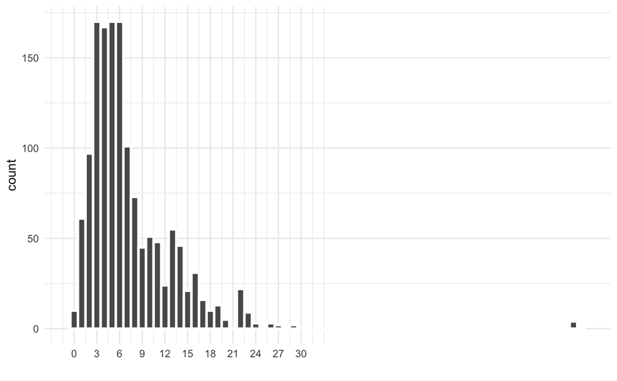

```r
contactGraph %>%
  inner_join(
    karCases %>%
      select(StateID, Date1=Date),
    by='StateID'
  ) %>%
  inner_join(
    karCases %>%
      select(ContactID=StateID, Date2=Date),
    by='ContactID'
  ) %>%
  mutate(DateDiff=as.numeric(Date1-Date2, units='days')) %>%
  ggplot(aes(x=DateDiff)) + geom_histogram(binwidth = 1, col='white', lwd=1)  + theme_minimal() + scale_x_continuous('', breaks=seq(0,30,3))
```

```r
contactGraph %>%
  inner_join(
    karCases %>%
      select(StateID, Date1=Date),
    by='StateID'
  ) %>%
  inner_join(
    karCases %>%
      select(ContactID=StateID, Date2=Date),
    by='ContactID'
  ) %>%
  mutate(DateDiff=as.numeric(Date1-Date2, units='days')) %>%
  count(ContactID, DateDiff, sort=T)
```

| ContactID | DateDiff | n |
| --- | --- | --- |
| KA-P4350 | 7 | 42 |
| KA-P2612 | 6 | 30 |
| KA-P533 | 5 | 19 |
| KA-P4184 | 8 | 18 |
| KA-P2608 | 6 | 17 |
| KA-P653 | 13 | 16 |
| KA-P2939 | 4 | 14 |
| KA-P653 | 11 | 14 |
| KA-P607 | 3 | 12 |
| KA-P659 | 3 | 12 |

[output cut: 614 more lines]

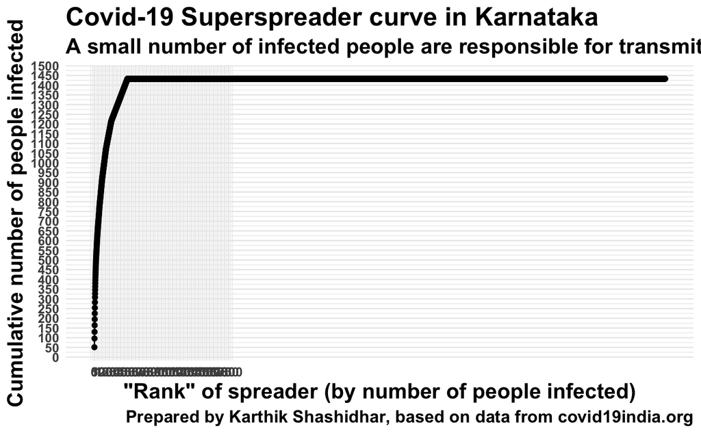

```r
contactGraph %>%
  count(ContactID, sort=T) %>%
  bind_rows(
    karCases %>%
      filter(Date < Sys.Date() -7) %>%
      select(ContactID=StateID) %>%
      mutate(n=0)

  ) %>%
  mutate(x=1:n(), y=cumsum(n)) %>%
  ggplot(aes(x=x, y=y)) + geom_point() + geom_line() + theme_minimal() + scale_x_continuous('"Rank" of spreader (by number of people infected)', breaks = seq(0,1800,50)) + scale_y_continuous("Cumulative number of people infected", breaks=seq(0, 1800,50)) + labs(title="Covid-19 Superspreader curve in Karnataka", subtitle='A small number of infected people are responsible for transmitting a large number of infections', caption='Prepared by Karthik Shashidhar, based on data from covid19india.org') + theme(text=element_text(face='bold', size=12), title=element_text(size=16, face='bold'))
```

```r
contactGraph %>%
  inner_join(karCases %>% select(StateID, Date), by = "StateID") %>%
  group_by(ContactID) %>%
  summarise(n=n(), Earliest=min(Date), Latest=max(Date)) %>%
  ungroup() %>%
  rename(StateID=ContactID) %>%
  inner_join(karCases %>% mutate(City=coalesce(City, District)) %>%select(StateID, Date,  Notes, City, Age, Sex), by = "StateID") %>%
  mutate(Notes=str_sub(Notes, 1, 60)) %>%
  arrange(-n) %>%
  mutate(CumNum=cumsum(n),Prop=scales::percent(cumsum(n)/sum(n),1), Num=1:n())
```

| StateID | n | Earliest | Latest | Date | Notes | City | Age | Sex | CumNum | Prop | Num |
| --- | --- | --- | --- | --- | --- | --- | --- | --- | --- | --- | --- |
| KA-P4350 | 51 | 2020-06-07 | 2020-06-18 | 2020-06-05 | Contact of KA-PBLR-53 | Ballari | 42 | M | 51 | 4% | 1 |
| KA-P653 | 45 | 2020-05-08 | 2020-05-18 | 2020-05-05 | Contact of KA-P420 | Bengaluru Urban | 34 | M | 96 | 7% | 2 |
| KA-P419 | 34 | 2020-04-23 | 2020-05-09 | 2020-04-22 | SARI. Worked at a scrap segregation unit at Hongasandra. | Bengaluru Urban | 54 | M | 130 | 9% | 3 |
| KA-P52 | 34 | 2020-03-29 | 2020-04-22 | 2020-03-26 | Had been in contact with healthcare professionals. No other | Mysuru | 35 | M | 164 | 11% | 4 |
| KA-P533 | 31 | 2020-05-01 | 2020-05-16 | 2020-04-29 | Influenza like Illness | Davanagere | 35 | F | 195 | 14% | 5 |
| KA-P2612 | 30 | 2020-06-04 | 2020-06-04 | 2020-05-29 | Travelled from Maharashtra | Raichur | 40 | M | 225 | 16% | 6 |
| KA-P4184 | 29 | 2020-06-08 | 2020-06-18 | 2020-06-04 | Travelled from Bengaluru | Ballari | 35 | M | 254 | 18% | 7 |
| KA-P221 | 28 | 2020-04-14 | 2020-05-06 | 2020-04-12 | SARI patient | Vijayapura | 60 | F | 282 | 20% | 8 |
| KA-P659 | 26 | 2020-05-08 | 2020-05-18 | 2020-05-05 | Influenza like illness | Bhatkal | 18 | F | 308 | 21% | 9 |
| KA-P2180 | 19 | 2020-05-30 | 2020-06-10 | 2020-05-25 | SARI | Bengaluru Urban | 38 | F | 327 | 23% | 10 |

[output cut: 435 more lines]

```r
contactGraph %>%
  inner_join(karCases %>% select(StateID, Date), by = "StateID") %>%
  group_by(ContactID) %>%
  summarise(n=n(), Earliest=min(Date), Latest=max(Date)) %>%
  ungroup() %>%
  rename(StateID=ContactID) %>%
  inner_join(karCases %>% mutate(City=coalesce(City, District)) %>%select(StateID, Date,  Notes, City, Age, Sex), by = "StateID") %>%
  mutate(Notes=str_sub(Notes, 1, 60)) %>%
  arrange(-n) %>%
  mutate(CumNum=cumsum(n),Prop=scales::percent(cumsum(n)/sum(n),1), Num=1:n()) %>%
  filter(str_detect(Notes, 'Return') | str_detect(Notes, 'Travel'))
```

| StateID | n | Earliest | Latest | Date | Notes | City | Age | Sex | CumNum | Prop | Num |
| --- | --- | --- | --- | --- | --- | --- | --- | --- | --- | --- | --- |
| KA-P2612 | 30 | 2020-06-04 | 2020-06-04 | 2020-05-29 | Travelled from Maharashtra | Raichur | 40 | M | 225 | 16% | 6 |
| KA-P4184 | 29 | 2020-06-08 | 2020-06-18 | 2020-06-04 | Travelled from Bengaluru | Ballari | 35 | M | 254 | 18% | 7 |
| KA-P2608 | 17 | 2020-06-04 | 2020-06-04 | 2020-05-29 | Travelled from Maharashtra | Raichur | 54 | F | 363 | 25% | 12 |
| KA-P128 | 14 | 2020-04-09 | 2020-05-02 | 2020-04-03 | Travelled to Delhi | Belagavi | 20 | M | 410 | 29% | 15 |
| KA-P2939 | 14 | 2020-06-04 | 2020-06-04 | 2020-05-31 | Travelled from Maharashtra | Raichur | 20 | M | 424 | 30% | 16 |
| KA-P869 | 12 | 2020-05-17 | 2020-05-25 | 2020-05-12 | Travelled from Mumbai, Maharastra | Mandya | 28 | M | 460 | 32% | 19 |
| KA-P167 | 11 | 2020-04-10 | 2020-04-18 | 2020-04-07 | Travelled to Delhi | Bengaluru | 29 | M | 471 | 33% | 20 |
| KA-P2641 | 9 | 2020-06-04 | 2020-06-04 | 2020-05-29 | Travelled from Maharashtra | Raichur | 22 | M | 511 | 36% | 24 |
| KA-P5813 | 7 | 2020-06-12 | 2020-06-16 | 2020-06-09 | Travelled from Andhra Pradesh | Tumakuru | 40 | M | 577 | 40% | 33 |
| KA-P19 | 6 | 2020-03-28 | 2020-04-09 | 2020-03-21 | Travelled from Mecca, Saudi Arabia | Gowribidanur | 32 | M | 615 | 43% | 39 |

[output cut: 83 more lines]

```r
contactGraph %>%
  filter(ContactID=='KA-P653')
```

| StateID | ContactID |
| --- | --- |
| KA-P708 | KA-P653 |
| KA-P709 | KA-P653 |
| KA-P710 | KA-P653 |
| KA-P711 | KA-P653 |
| KA-P1017 | KA-P653 |
| KA-P1018 | KA-P653 |
| KA-P1019 | KA-P653 |
| KA-P1020 | KA-P653 |
| KA-P1021 | KA-P653 |
| KA-P1022 | KA-P653 |

[output cut: 35 more lines]

```r
contactGraph %>%
  filter(StateID=='KA-P196')
```

| StateID | ContactID |
| --- | --- |

```r
karCases %>%
  filter(str_detect(Notes, 'P128'))
```

| Date | StateID | City | District | Status | Notes | Age | Sex | Transmission | MoreNotes | NoteLength |
| --- | --- | --- | --- | --- | --- | --- | --- | --- | --- | --- |
| 2020-04-09 | KA-P182 | NA | Belagavi | Hospitalized | Contact of P128 (Father) | 50 | M | Local | NA | 24 |
| 2020-04-09 | KA-P192 | NA | Belagavi | Hospitalized | Contact of P128 - Mother | 40 | F | Local | NA | 24 |
| 2020-04-09 | KA-P193 | NA | Belagavi | Hospitalized | Contact of P128 - Brother | 22 | M | Local | NA | 25 |
| 2020-04-12 | KA-P224 | Hirebagewadi | Belagavi | Hospitalized | Contact of KA-P128 | 38 | M | Local | NA | 18 |
| 2020-04-25 | KA-P482 | NA | Belagavi | Hospitalized | Secondary contact of KA-P128 | 45 | M | NA | NA | 28 |
| 2020-04-25 | KA-P483 | NA | Belagavi | Hospitalized | Secondary contact of KA-P128 | 38 | M | NA | NA | 28 |
| 2020-04-25 | KA-P484 | NA | Belagavi | Hospitalized | Secondary contact of KA-P128 | 80 | F | NA | NA | 28 |
| 2020-04-25 | KA-P485 | NA | Belagavi | Hospitalized | Secondary contact of KA-P128 | 55 | F | NA | NA | 28 |
| 2020-04-25 | KA-P486 | NA | Belagavi | Hospitalized | Secondary contact of KA-P128 | 42 | F | NA | NA | 28 |
| 2020-04-25 | KA-P487 | NA | Belagavi | Hospitalized | Secondary contact of KA-P128 | 39 | F | NA | NA | 28 |

[output cut: 4 more lines]

```r
latestContacts <- contactGraph %>%
  mutate(Level=1)
i <- 2
allContacts <- latestContacts
while(nrow(latestContacts) > 0) {
  latestContacts %>%
    select(-Level) %>%
    left_join(
      contactGraph %>%
        select(
          Contact2ID=ContactID,
          ContactID=StateID
        ),
      by = "ContactID"
    ) %>%
    select(-ContactID) %>%
    filter(!is.na(Contact2ID)) %>%
    rename(ContactID=Contact2ID) %>%
    mutate(Level=i) ->
    latestContacts

  allContacts %>%
    bind_rows(latestContacts) ->
    allContacts
  i <- i + 1
  print(paste(i, Sys.time()))

}
```

```
[1] "3 2020-06-23 17:54:52"
[1] "4 2020-06-23 17:54:52"
[1] "5 2020-06-23 17:54:52"
[1] "6 2020-06-23 17:54:52"
[1] "7 2020-06-23 17:54:52"
```

```r
allContacts %>%
  inner_join(
    karCases %>%
      select(StateID, Date),
    by='StateID'
  ) %>%
  ungroup() %>%
  group_by(StateID=ContactID) %>%
  summarise(n=n()+1, Earliest=min(Date), Latest=max(Date)) %>%
  inner_join(karCases %>% mutate(City=coalesce(City, District)) %>%select(StateID, Notes, City, Age, Sex), by = "StateID") %>%
  mutate(Notes=str_sub(Notes, 1, 80)) %>%
  arrange(-n)
```

| StateID | n | Earliest | Latest | Notes | City | Age | Sex |
| --- | --- | --- | --- | --- | --- | --- | --- |
| KA-P4350 | 116 | 2020-06-07 | 2020-06-19 | Contact of KA-PBLR-53 | Ballari | 42 | M |
| KA-P4184 | 58 | 2020-06-08 | 2020-06-19 | Travelled from Bengaluru | Ballari | 35 | M |
| KA-P52 | 58 | 2020-03-29 | 2020-06-16 | Had been in contact with healthcare professionals. No other contact histroy or t | Mysuru | 35 | M |
| KA-P556 | 58 | 2020-05-01 | 2020-06-11 | SARI | Davanagere | 69 | M |
| KA-P221 | 56 | 2020-04-14 | 2020-05-17 | SARI patient | Vijayapura | 60 | F |
| KA-P196 | 49 | 2020-04-11 | 2020-05-18 | SARI | Bengaluru Urban | 42 | M |
| KA-P208 | 48 | 2020-04-22 | 2020-05-18 | Contact of KA-P196 | Bengaluru | 32 | M |
| KA-P420 | 47 | 2020-05-05 | 2020-05-18 | Contact of KA-P208 | Bengaluru Urban | 28 | F |
| KA-P653 | 46 | 2020-05-08 | 2020-05-18 | Contact of KA-P420 | Bengaluru Urban | 34 | M |
| KA-P533 | 45 | 2020-05-01 | 2020-05-27 | Influenza like Illness | Davanagere | 35 | F |

[output cut: 435 more lines]

```r
karCases %>%
  filter(StateID=='KA-P125')
```

| Date | StateID | City | District | Status | Notes | Age | Sex | Transmission | MoreNotes | NoteLength |
| --- | --- | --- | --- | --- | --- | --- | --- | --- | --- | --- |
| 2020-04-03 | KA-P125 | NA | Bagalkote | Deceased | NA | 75 | M | TBD | NA | NA |

Now let’s try the Lebanon algorithm

```r
# Let's put 1% as the cutoff
# Any region with more than 1% of cases needs its own category
totalCases <- dailyCases %>%
  summarise(Total=sum(Cases)) %>%
  pull(Total) %>%
  first()
cutoff <- 0.01
dailyCases %>%
  filter(!is.na(City)) %>%
  group_by(City, District, State) %>%
  summarise(Cases=sum(Cases)) %>%
  mutate(Share=Cases/totalCases) %>%
  filter(Share > cutoff) ->
  level0
level0 %>%
  arrange(-Cases) %>%
  group_by(State, District) %>%
  summarise(
    Lower=sum(Cases),
    Label=paste(City, collapase=', ')
  ) ->
  level01
dailyCases %>%
  filter(!is.na(District)) %>%
  group_by(District, State) %>%
  summarise(Cases=sum(Cases)) %>%
  left_join(
    level01,
    by=c("State","District")
  ) %>%
  ungroup() %>%
  mutate(
    Lower=ifelse(is.na(Lower), 0, Lower),
    Cases=Cases-Lower,
    District=ifelse(Lower > 0, paste0(District, " - {", Label, "}"), District)
  ) %>%
  mutate(Share=Cases/totalCases) %>%
  filter(Share > cutoff) ->
  level1
level1 %>%
  arrange(-Cases) %>%
  group_by(State) %>%
  summarise(
    Lower=sum(Cases),
    Label=paste(District, collapse=', ')
  ) ->
  level11
dailyCases %>%
  group_by(State) %>%
  summarise(Cases=sum(Cases)) %>%
  left_join(
    level11,
    by=c("State")
  ) %>%
  ungroup() %>%
  mutate(
    Lower=ifelse(is.na(Lower), 0, Lower),
    Cases=Cases-Lower,
    State=ifelse(Lower > 0, paste0(State, " - {", Label, "}"), State)
  ) %>%
  mutate(Share=Cases/totalCases) %>%
  filter(Share > cutoff) ->
  level2
bind_rows(
  level0 %>%
    ungroup() %>%
    mutate(Region=paste0(City, ' (', District, ' ', State, ')')) %>%
    select(Region, Cases, Share),
  level1 %>%
    ungroup() %>%
    mutate(Region=paste0(District, ' (', State, ')')) %>%
    select(Region, Cases, Share),
  level2 %>%
    ungroup() %>%
    mutate(Region=paste(State, sep=' - ')) %>%
    select(Region, Cases, Share)
) %>%
  arrange(-Share) %>%
  mutate(Cumul=cumsum(Share))
```

| Region | Cases | Share | Cumul |
| --- | --- | --- | --- |
| Mumbai (Maharashtra) | 65104 | 0.15957723 | 0.1595772 |
| Delhi | 55097 | 0.13504895 | 0.2946262 |
| Chennai (Tamil Nadu) | 38820 | 0.09515219 | 0.3897784 |
| Maharashtra - {Mumbai, Thane, Pune} | 27549 | 0.06752570 | 0.4573041 |
| Thane (Maharashtra) | 22356 | 0.05479707 | 0.5121011 |
| Ahmedabad (Gujarat) | 19450 | 0.04767414 | 0.5597753 |
| Uttar Pradesh | 17071 | 0.04184294 | 0.6016182 |
| Tamil Nadu - {Chennai} | 16271 | 0.03988205 | 0.6415003 |
| Pune (Maharashtra) | 14886 | 0.03648726 | 0.6779875 |
| Rajasthan | 14448 | 0.03541367 | 0.7134012 |

[output cut: 15 more lines]

Now if we have top 10 or something, then the “rest” should also come into the picture. How do we do this?

And nothing should come in negatives if it isn’t there in positives. So those should be “added back”.

Input parameters - how many, and what cumulative proportion should be covered. But that can’t work. If i say “10 things accounting for 70%”, it depends upon the distribution. Top 10 may not account for 70%. Maybe I should just have it as “top 10” or “top 70%”.

Can I do a 2 pass thingy?

```r
dailyCases %>%
  mutate(State=str_to_title(State), District=str_to_title(District), City=str_to_title(City)) %>%
  group_by(Level1=State, Level2=District, Level3=City) %>%
  summarise(Cases=sum(Cases)) %>%
  filter(Cases > 0) ->
  caseData
caseData %>%
  arrange(-Cases)
```

| Level1 | Level2 | Level3 | Cases |
| --- | --- | --- | --- |
| Maharashtra | Mumbai | NA | 64942 |
| Delhi | NA | NA | 55047 |
| Tamil Nadu | Chennai | NA | 38822 |
| Maharashtra | Thane | NA | 22018 |
| Gujarat | Ahmedabad | NA | 19426 |
| Maharashtra | Pune | NA | 14693 |
| State Unassigned | Unassigned | NA | 9258 |
| West Bengal | Kolkata | NA | 4539 |
| Telangana | Hyderabad | NA | 4378 |
| Madhya Pradesh | Indore | NA | 4291 |

[output cut: 990 more lines]

```r
topClusters <- function(caseData, numRows=NA, coverage=NA, levelDiscount=5) {

  caseData %>%
    group_by(Region=Level1) %>%
    summarise(Cases=sum(Cases), Successors=length(unique(Level2, na.rm=T))) %>%
    mutate(Level=1) %>%
    bind_rows(
      caseData %>%
        group_by(Region=Level2) %>%
        summarise(Cases=sum(Cases, Successors=length(unique(Level3, na.rm=T)))) %>%
        mutate(Level=2)
    ) %>%
    bind_rows(
      caseData %>%
        group_by(Region=Level3) %>%
        summarise(Cases=sum(Cases), Successors=1) %>%
        mutate(Level=3)
    ) %>%
    filter(!is.na(Region)) %>%
    arrange(-Cases) %>%
    mutate(CasesAdjusted=Cases*(levelDiscount^Level)) %>%
    arrange(-CasesAdjusted)


}
levelDiscount <- 5
```

Let’s just look at the Karnataka districts

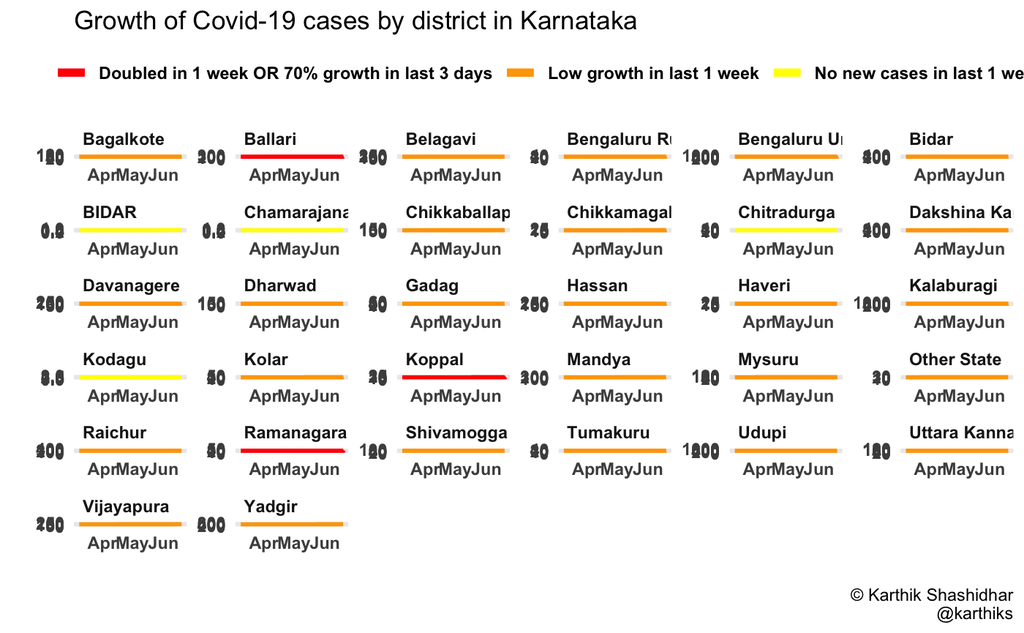

```r
dailyCases %>%
  filter(!is.na(Date)) %>%
  group_by(Date, District, State) %>%
  summarise(n=sum(Cases)) %>%
  ungroup() %>%
  filter(State=="Karnataka") %>%
  ungroup() %>%
  complete(District, Date, fill = list(n=0)) %>%
  arrange(District, Date) %>%
  group_by(District) %>%
  mutate(
    Total=cumsum(n),
    Latest=Total[Date==max(Date)],
    Back1week=Total[Date==(max(Date)-7)],
    Back3days=Total[Date==(max(Date)-3)],
    WeekGrowth=Latest/Back1week-1,
    Growth3=Latest/Back3days-1,
    colour=ifelse(Latest==Back1week, 'No new cases in last 1 week', ifelse((Back1week==0 & Latest > 0) | WeekGrowth > 1 | Growth3 > 0.7, 'Doubled in 1 week OR 70% growth in last 3 days', 'Low growth in last 1 week'))
  ) %>%
  ggplot(aes(x=Date, y=Total, col=colour)) + geom_line(lwd=2) + facet_wrap(~District, scales='free') + theme_minimal() + scale_y_continuous('', breaks= scales::pretty_breaks()) + scale_x_date('') + scale_colour_manual(values = c('red', 'orange', 'yellow')) + theme(strip.text = element_text(face='bold', hjust=0), legend.position = 'top', legend.title = element_blank(), legend.text = element_text(face='bold'), axis.text = element_text(face='bold')) + labs(title="Growth of Covid-19 cases by district in Karnataka", caption='© Karthik Shashidhar\n  @karthiks')
```

Do it on a choropleth

```r
require(sf)
kar <- st_read('~/Documents/work/data work/maps/maps/Districts/Census_2011/2011_Dist.shp') %>%
  filter(ST_NM=='Karnataka')
```

[output not shown]

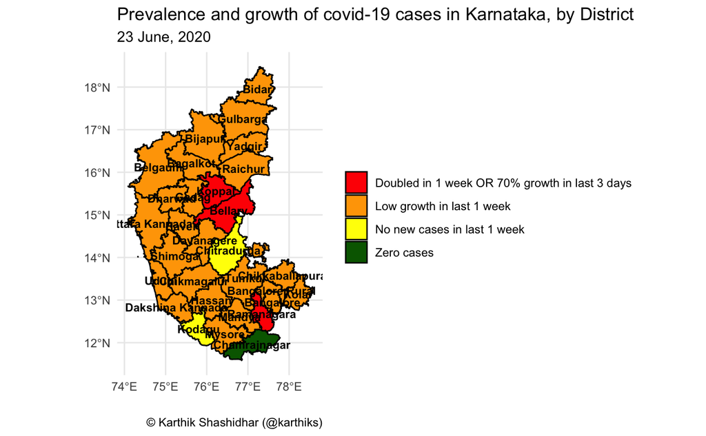

```r
kar %>%
  mutate(DISTRICT=as.character(DISTRICT)) %>%
  left_join(
    dailyCases %>%
      filter(!is.na(Date)) %>%
      group_by(Date, District, State) %>%
      summarise(n=sum(Cases)) %>%
      ungroup() %>%
      filter(State=="Karnataka") %>%
      ungroup() %>%
      complete(District, Date, fill = list(n=0)) %>%
      arrange(District, Date) %>%
      group_by(District) %>%
      mutate(
        Total=cumsum(n),
        Latest=Total[Date==max(Date)],
        Back1week=Total[Date==(max(Date)-7)],
        Back3days=Total[Date==(max(Date)-3)],
        WeekGrowth=Latest/Back1week-1,
        Growth3=Latest/Back3days-1,
        colour=ifelse(Latest==Back1week, 'No new cases in last 1 week', ifelse((Back1week==0 & Latest > 0) | WeekGrowth > 1 | Growth3 > 0.7, 'Doubled in 1 week OR 70% growth in last 3 days', 'Low growth in last 1 week'))
      ) %>%
      distinct(District, colour) %>%
      left_join(
        tibble(
          District=c('Bagalkote', 'Ballari', 'Belagavi', 'Bengaluru Urban', "Bengaluru Rural", "Kalaburagi", 'Mysuru', 'Tumakuru', 'Vijayapura', 'Shivamogga', 'Chikkamagaluru'),
          DISTRICT=c('Bagalkot', 'Bellary', 'Belgaum', 'Bangalore', 'Bangalore Rural', 'Gulbarga', 'Mysore', 'Tumkur' , 'Bijapur', 'Shimoga', 'Chikmagalur')
        ),
        by='District'
      ) %>%
      mutate(DISTRICT=coalesce(DISTRICT, District)) %>%
      ungroup() %>%
      distinct(DISTRICT, colour),
    by='DISTRICT'
  ) %>%
  mutate(colour=coalesce(colour, 'Zero cases')) %>%
  ggplot() + geom_sf(aes(fill=colour), col='black') + geom_text(data=st_coordinates(st_centroid(kar)) %>% as_tibble() %>% mutate(DISTRICT=kar$DISTRICT), aes(x=X, y=Y, label=DISTRICT), fontface='bold', size=3)+  scale_fill_manual(values = c('red', 'orange', 'yellow', 'darkgreen'))+ theme_minimal() + theme(legend.position = 'right', legend.title = element_blank()) + labs(title="Prevalence and growth of covid-19 cases in Karnataka, by District", subtitle = format(Sys.Date(), '%d %B, %Y'), caption="© Karthik Shashidhar (@karthiks)") + xlab('') + ylab('')
```

```r
read_csv('https://api.covid19india.org/csv/latest/statewise_tested_numbers_data.csv', col_types = cols()) %>%
  mutate(
    Date=as.Date(`Updated On`, '%d/%m/%Y'),
    Tested=as.numeric(`Total Tested`)
  ) %>%
  rename(state=State) ->
  covidtests
```

[output not shown]

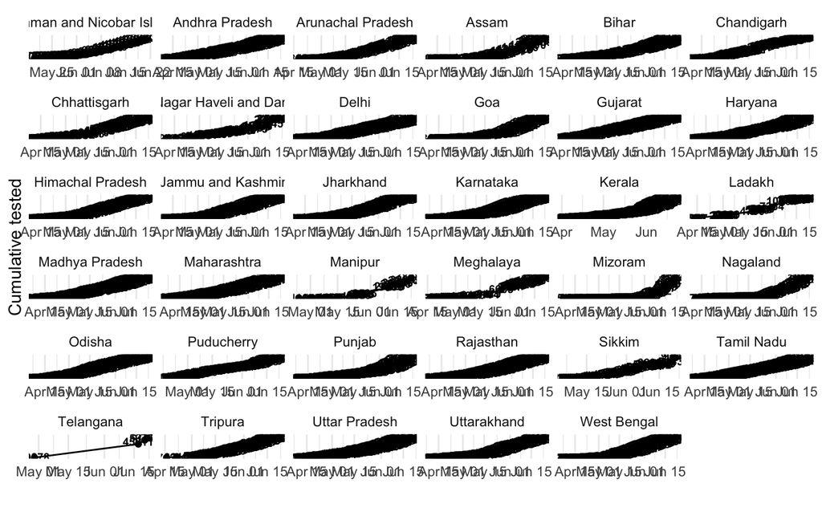

```r
covidtests %>%
  distinct(state, Date, Tested) %>%
  filter(!is.na(Tested)) %>%
  group_by(state) %>%
  arrange(state, Date) %>%
  mutate(
    TestedToday=Tested-lag(Tested, 1),
    DateDiff=as.numeric(Date-lag(Date, 1), units='days')
  ) %>%
  filter(n() > 5 & !is.na(DateDiff) & DateDiff==1) %>%
  ggplot(aes(x=Date, y=Tested, label=Tested)) + geom_point() + geom_line() + geom_text(aes(y=1.1*Tested), fontface='bold', size=2.5) + theme_minimal() + facet_wrap(~state, scales='free') + xlab('') + scale_y_continuous("Cumulative tested", breaks=c())
```

```r
covidtests %>%
  distinct(state, Date, Tested) %>%
  filter(!is.na(Tested)) %>%
  group_by(state) %>%
  arrange(state, Date) %>%
  mutate(
    TestedToday=Tested-lag(Tested, 1),
    DateDiff=as.numeric(Date-lag(Date, 1), units='days')
  ) %>%
  filter(n() > 5 & !is.na(DateDiff) & DateDiff==1 & state=='Karnataka')
```

| state | Date | Tested | TestedToday | DateDiff |
| --- | --- | --- | --- | --- |
| Karnataka | 2020-04-08 | 6967 | 387 | 1 |
| Karnataka | 2020-04-09 | 7613 | 646 | 1 |
| Karnataka | 2020-04-10 | 7975 | 362 | 1 |
| Karnataka | 2020-04-11 | 8560 | 585 | 1 |
| Karnataka | 2020-04-12 | 9251 | 691 | 1 |
| Karnataka | 2020-04-13 | 10017 | 766 | 1 |
| Karnataka | 2020-04-14 | 11107 | 1090 | 1 |
| Karnataka | 2020-04-15 | 12483 | 1376 | 1 |
| Karnataka | 2020-04-16 | 13724 | 1241 | 1 |
| Karnataka | 2020-04-17 | 17594 | 3870 | 1 |

[output cut: 66 more lines]

Let’s plot testing as well as positive cases

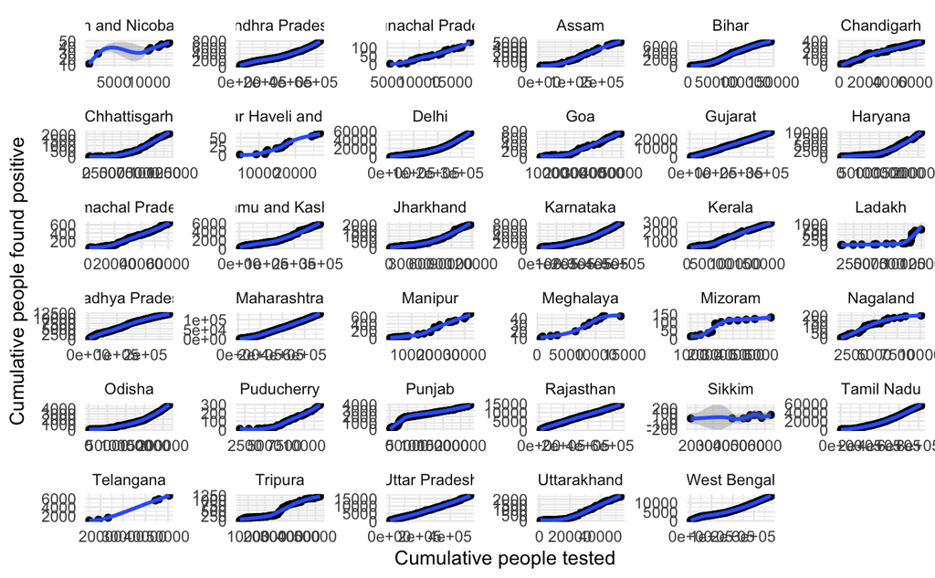

```r
covidtests %>%
  distinct(state, Date, Tested) %>%
  inner_join(
    dailyCases %>%
      filter(!is.na(Date)) %>%
      group_by(Date, State) %>%
      summarise(Positive=sum(Cases)) %>%
      ungroup() %>%
      rename(state=State) %>%
      arrange(state, Date) %>%
      group_by(state) %>%
      mutate(Positive=cumsum(Positive)),
    by=c("Date", "state")
  ) %>%
  filter(complete.cases(.)) %>%
  group_by(state) %>%
  filter(n() > 5) %>%
  ggplot(aes(x=Tested, y=Positive, label=format(Date, '%d-%m'))) + geom_point() + geom_smooth(method='loess', formula='y~x') + facet_wrap(~state, scales='free') + theme_minimal()  + xlab("Cumulative people tested") + ylab("Cumulative people found positive")
```

State-wise coloured graph

```r
covidtests %>%
  distinct(state, Date, Tested) %>%
  arrange(state, Date) %>%
  filter(!is.na(Tested)) %>%
  group_by(state) %>%
  mutate(
    NewTests=Tested-lag(Tested, 1)
  ) %>%
  filter(!is.na(NewTests) & NewTests > 0) %>%
  mutate(
    DateDiff=as.numeric(Date-lag(Date,1))
  ) %>%
  filter(DateDiff==1) %>%
  filter(n() >= 5) %>%
  inner_join(
    dailyCases %>%
      filter(!is.na(Date)) %>%
      group_by(Date, State) %>%
      summarise(Positive=sum(Cases)) %>%
      ungroup() %>%
      rename(state=State) %>%
      arrange(state, Date) %>%
      group_by(state) %>%
      mutate(Positive=cumsum(Positive)),
    by=c("Date", "state")
  ) %>%
  ungroup() %>%
  filter(complete.cases(.)) %>%
  group_by(state) %>%
  arrange(state, Date) %>%
  mutate(
    TestsPerPositive=Tested/Positive,
    BetterTesting=TestsPerPositive > lag(TestsPerPositive, 1),
    LastBig=as.numeric(Sys.Date()-max(Date[!is.na(BetterTesting) & !BetterTesting]))
  ) %>%
  distinct(state, LastBig) %>%
  ungroup() %>%
  mutate(
    LastBig=ifelse(LastBig==Inf,NA,LastBig),
    LastBig=coalesce(LastBig, max(LastBig, na.rm=T)),
    BlueNess=(LastBig-min(LastBig))/(max(LastBig)-min(LastBig)),
    Colour=rgb(1,0.4+BlueNess*0.6,0.4-BlueNess*0.4)
  )%>%
  distinct(state, Colour) ->
  stateColours
covidtests %>%
  distinct(state, Date, Tested) %>%
  inner_join(
    dailyCases %>%
      filter(!is.na(Date)) %>%
      group_by(Date, State) %>%
      summarise(Positive=sum(Cases)) %>%
      ungroup() %>%
      rename(state=State) %>%
      arrange(state, Date) %>%
      group_by(state) %>%
      mutate(Positive=cumsum(Positive)),
    by=c("Date", "state")
  ) %>%
  filter(complete.cases(.)) %>%
  group_by(state) %>%
  filter(n() > 5) ->
  stateTestCases
stateColours %>%
  filter(state %in% stateTestCases$state) ->
  stateColours
stateGraphs <- list()
for(i in 1:nrow(stateColours)) {
  stateTestCases %>%
    filter(state==stateColours$state[i]) %>%
    ggplot(aes(x=Tested, y=Positive, label=format(Date, '%d-%m'))) + geom_point() + geom_smooth(method='loess', formula='y~x') + theme_minimal()  + scale_x_continuous("Total tests", labels=scales::label_number_si()) + scale_y_continuous("Total Positive Cases") + ggtitle(stateColours$state[i]) + theme(plot.background = element_rect(fill=stateColours$Colour[i]), title=element_text(face='bold', size=16), text=element_text(face='bold', size=10)) ->
    stateGraphs[[i]]
}
require(patchwork)
stateGraphs %>% wrap_plots(nrow=3, guides = 'collect') ->
  p
ggsave('tmp.png', p, width=20, height=10, units='in')
```

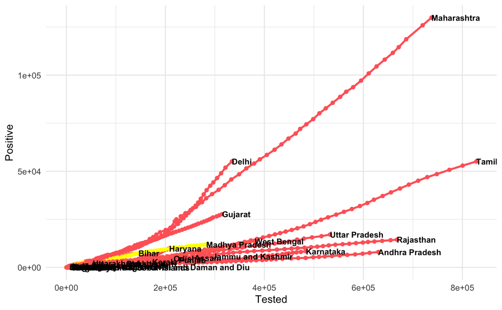

```r
stateTestCases %>%
  group_by(state) %>%
  mutate(Label=ifelse(Date==max(Date), state, '')) %>%
  inner_join(stateColours, by='state') %>%
  ggplot(aes(x=Tested, y=Positive, group=state, col=Colour, label=Label)) + geom_line(lwd=1) + geom_point() + geom_text(nudge_x=10,fontface='bold', col='black', size=3, hjust=0)+ scale_colour_identity() + theme_minimal()
```

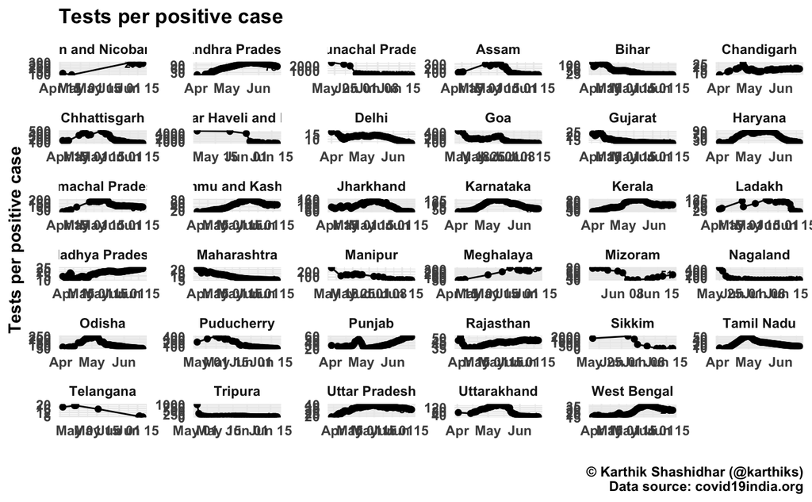

```r
stateTestCases %>%
  group_by(state) %>%
  mutate(
    Ratio=Tested/Positive,
    Label=ifelse(Date==max(Date), round(Ratio), '')
  ) %>%
  ggplot(aes(x=Date, y=Ratio, label=Label)) + geom_point() + geom_line() + geom_text(hjust=1, nudge_y=1, fontface='bold', size=2.5) + facet_wrap(~state, scales='free') + theme_minimal() + xlab('') + ylab("Tests per positive case")+ labs(title="Tests per positive case", caption="© Karthik Shashidhar (@karthiks)\n Data source: covid19india.org" ) + theme(title=element_text(face='bold'), text=element_text(face='bold'))
```

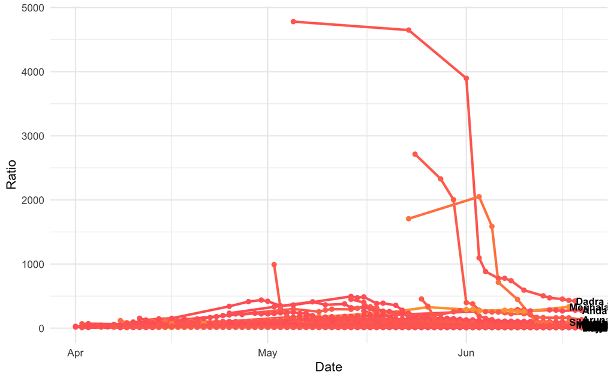

```r
stateTestCases %>%
  group_by(state) %>%
  mutate(
    Label=ifelse(Date==max(Date), state, ''),
    Ratio=Tested/Positive
  ) %>%
  inner_join(stateColours, by='state') %>%
  ggplot(aes(x=Date, y=Ratio, group=state, col=Colour, label=Label)) + geom_line(lwd=1) + geom_point() + geom_text(nudge_x=0.1,fontface='bold', col='black', size=3, hjust=0)+ scale_colour_identity() + theme_minimal()
```

[figure not shown]

```r
p
```

Now let’s try multiple Y axes Data is same

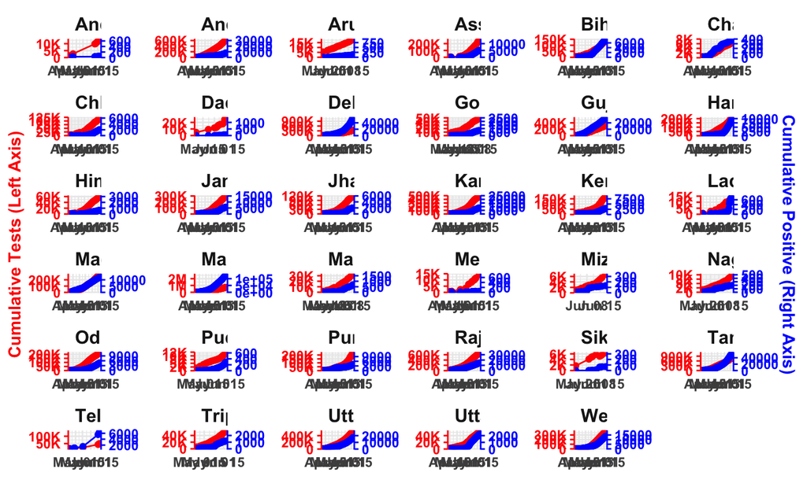

```r
covidtests %>%
  distinct(state, Date, Tested) %>%
  inner_join(
    dailyCases %>%
      filter(!is.na(Date)) %>%
      group_by(Date, State) %>%
      summarise(Positive=sum(Cases)) %>%
      ungroup() %>%
      rename(state=State) %>%
      arrange(state, Date) %>%
      group_by(state) %>%
      mutate(Positive=cumsum(Positive)),
    by=c("Date", "state")
  ) %>%
  filter(complete.cases(.) & Date >= as.Date('2020-04-07')) %>%
  group_by(state) %>%
  filter(n() > 5) %>%
  ggplot(aes(x=Date, y=Tested, col='tested')) + geom_line() + geom_point() + geom_point(aes(y=Positive*20, col='Positive')) + geom_line(aes(y=Positive*20, col='Positive')) + scale_y_continuous("Cumulative Tests (Left Axis)", sec.axis = sec_axis(~./20, name='Cumulative Positive (Right Axis)'), labels=scales::label_number_si()) + facet_wrap(~state, scales='free') + scale_colour_manual(values=c('blue', 'red')) + theme_minimal() + theme(axis.line.y.left = element_line(colour='red'), axis.text.y.left = element_text(colour='red', face='bold'), axis.ticks.y.left = element_line(colour='red'), axis.line.y.right = element_line(colour='blue'), axis.text.y.right = element_text(colour='blue', face='bold'), axis.ticks.y.right = element_line(colour='blue'), axis.title.y.right = element_text(colour='blue', face='bold'), axis.title.y.left=element_text(colour='red', face='bold'), legend.position='none', strip.text = element_text(face='bold', size=12, hjust=0), axis.text.x = element_text(face='bold')) + xlab('')
```